# Electronic Patient-Provider Communication in Secure Messages

[figure not shown]

[figure not shown]

[figure not shown]

[figure not shown]

[figure not shown]

[figure not shown]

[figure not shown]

[figure not shown]

[figure not shown]

[figure not shown]

# Total count since 2012

### **Count of Secure Messages by Year**

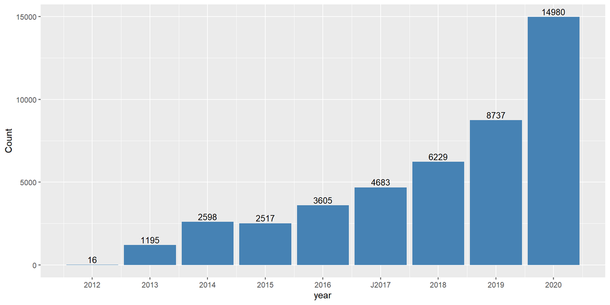

# Monthly Counts per Year

### **2012**

**Count of Secure Messages by Month in 2012**

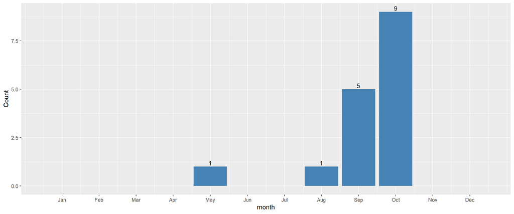

### **2013**

**Count of Secure Messages by Month in 2013**

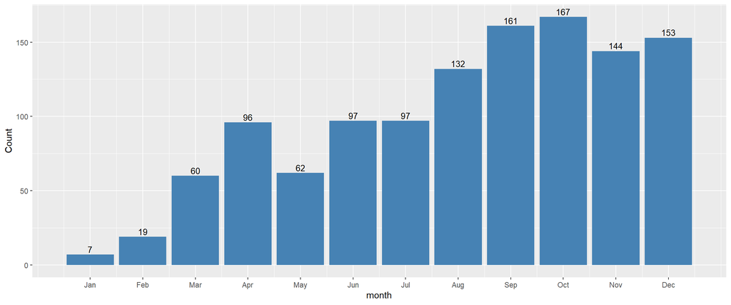

### **2014**

**Count of Secure Messages by Month in 2014**

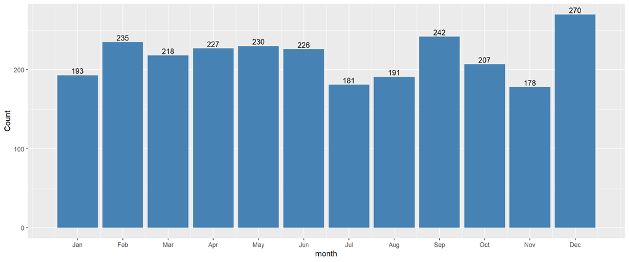

### **2015**

**Count of Secure Messages by Month in 2015**

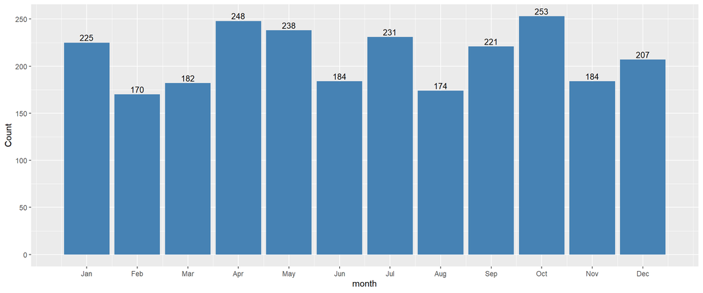

### **2016**

**Count of Secure Messages by Month in 2016**

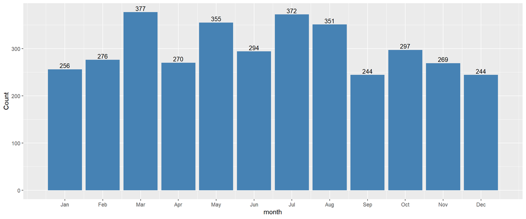

### **2017**

**Count of Secure Messages by Month in 2017**

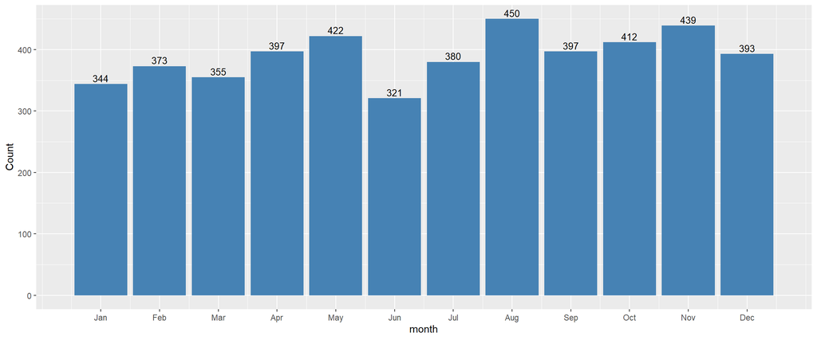

### **2018**

**Count of Secure Messages by Month in 2018**

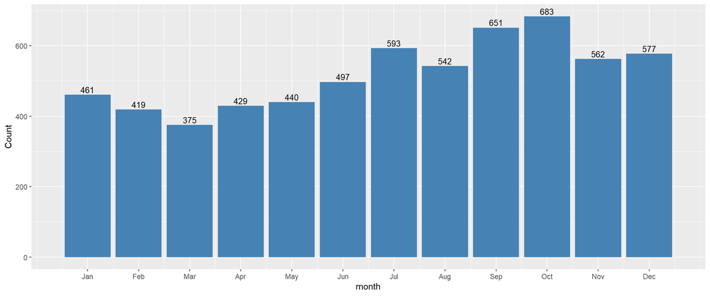

### **2019**

**Count of Secure Messages by Month in 2019**

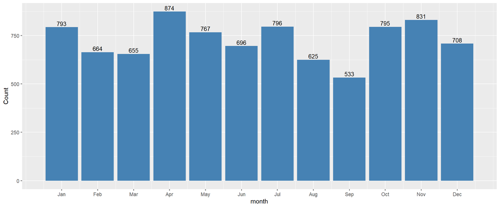

### **2020**

**Count of Secure Messages by Month in 2020**

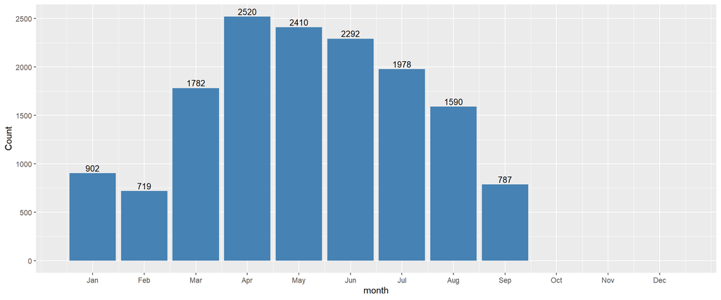

# Manual coding of secure messages

### **Manual coding of secure messages**

This tab demonstrates examples of manual coding of secure messages. We adapted multiple sources to generate our own codebook that we will use to annotate and code patient-provider communication codes in secure messages. This codebook will be updated as we continue to manually code the dataset of secure messages as described in the proposal.

| **Patient-Provider Communication Code** | **Operational Definition** |
| --- | --- |
| **Partnership** | Requests for opinion, understanding, paraphrase and interpretations, and facilitating patient participation by equalizing status*<sup>a</sup>* |
| **Emotional Support** | Statements or inquiries to generate reassurance, support, empathy, and other verbal displays of sensitivity*<sup>b</sup>* |
| **Information-Giving** | Information provided in response to statements, questions, emotional expressions, or spontaneous information unrelated to previous statements or inquiries*<sup>c</sup>* |
| **Information-Seeking** | Obtaining knowledge of a specific event or situation to attain, clarify, or confirm information*<sup>d, e</sup>* |
| **Shared Decision-Making** | A two-way exchange of information and/or treatment preferences in which all parties participate in the decision-making process*<sup>f</sup>* |
| **Empathy** | Explicit statements of emotion, or opportunities/recognition in which an inference of an underlying emotion has/has not been explicitly expressed*<sup>g</sup>* |

*<sup>a</sup>* Adapted from Roter, D. L., & Hall, J. A. (2004). Physician gender and patient-centered communication: a critical review of empirical research. Annu. Rev. Public Health, 25, 497-519.

*<sup>b</sup>* Adapted from Street Jr, R. L., & Millay, B. (2001). Analyzing patient participation in medical encounters. Health communication, 13(1), 61-73.

*<sup>c</sup>* Adapted from Ishikawa, H., Son, D., Eto, M., Kitamura, K., & Kiuchi, T. (2017). The information-giving skills of resident physicians: relationships with confidence and simulated patient satisfaction. BMC Medical, 17(1), 34.

*<sup>d</sup>*Adapted from Barsevick, A. M., & Johnson, J. E. (1990). Preference for information and involvement, information seeking and emotional responses of women undergoing colposcopy. Research in nursing & health, 13(1), 1-7.

*<sup>e</sup>* Adapted from Corbo-Richert, B., Caty, S., & Barnes, C. M. (1993). Coping behaviors of children hospitalized for cardiac surgery: A secondary analysis. Maternal-Child Nursing Journal, 21(1), 27–36.

*<sup>f</sup>* Adapted from Charles, C., Gafni, A., & Whelan, T. (1997). Shared decision-making in the medical encounter: what does it mean?(or it takes at least two to tango). Social science & medicine, 44(5), 681-692.

*<sup>g</sup>*Adapted from Suchman, A. L., Markakis, K., Beckman, H. B., & Frankel, R. (1997). A model of empathic communication in the medical interview. Jama, 277(8), 678-682.

### **Examples of coded text in secure messages**

| **Examples of coded text in secure messages** |
| --- |
| *Hi There Ive got the questions here and I will give this to Dr to* discuss with at the appt *Thank you* |
| *Dr Is there any chance I could be given a summary of the procedure and what was done without having to wait until March 24th as* the wait is driving me nuts with the thought of what could be It would… |
| *Can you let me know the results* *of the skin test for shingles from 1223 I could not find it in the tests tab Thanks -- -Anita* |
| *Hi Dr: When we spoke a week or so ago you were going to initiate a process to see if my Dad's insurance would cover the suggested chemo drug called Aduoradoline The good news is my dad received a pho… |
| *I understand your concern* *but Dr is away for a few days I have you message and will give it to him tomorrow if he is reachable if not for sure on Friday when he is back in the office* |

# Clusters/Topics in messages

### **Clusters/Topics in messages**

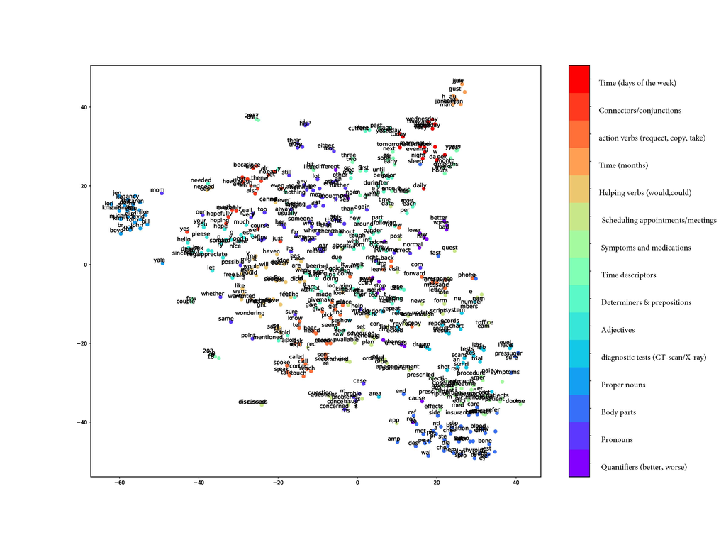